# act_report

### Twitter users activity on WeRateDogs Portal

#### Data Analysis & Visualization

I downloaded the Twitter data for the WeRateDogs website. The final dataset contained 2046 tweets. My first major focus went on with the retweet and favorites count. The distribution below shows with the actual data and log Transformed data. The reason why I have transformed into a log is to make the distrubution plot to near normal. From the below graphs it clearly shows that only very few tweets have higher Retweets and favorites, and majority of them fall into right tail distribution.

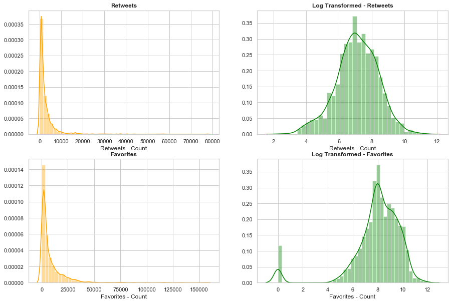

```python
from IPython.display import Image
Image(filename='retweetsVSfavorites.png')
```

Next I tried to check if there are any correlations with the numeric attributes with a major focus on Favorites and Retweets.

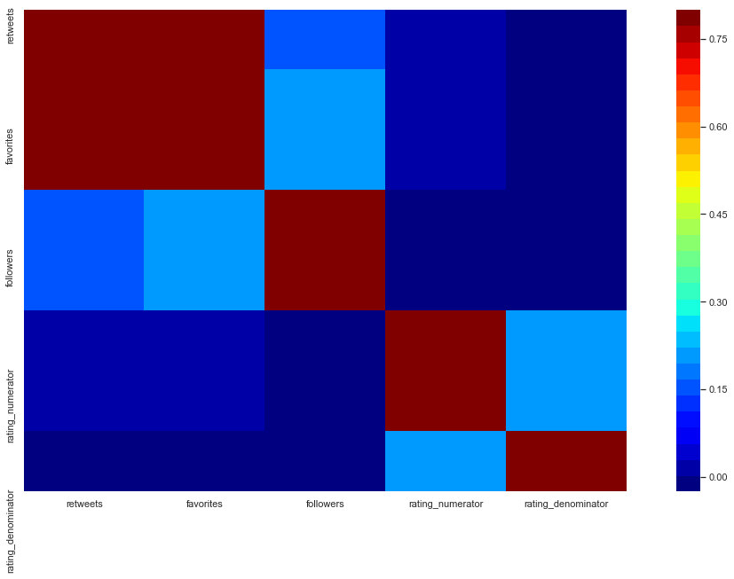

```python
from IPython.display import Image
Image(filename='corr_plot.png')
```

It seems like Retweets and Favorites are highly correlated.This shows that people who have retweeted have also done with favorites tag. Hence both the distributions shows similar behaviour

To confirm this correlation, I checked for a scatter plot between Retweets and Favorites. It clearly shows from below that they both follow a similar trend and go in sync together.

There is a very strong relationship between retweet and favorite counts. As the user shows interest on Favorites, one can expect to see Retweets to increase and vice versa.

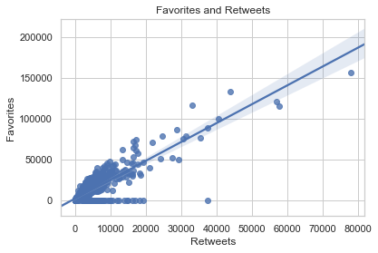

```python
from IPython.display import Image
Image(filename='scatterplot.png')
```

Now the twitter look has changed instead of favorite, I am seeing the "like" option.

So from here we can also interpret that most of the users do a like or favorite because it acts like a bookmark thing which can help them to review back again.

Retweets are not saved in the twitter profile. The above analysis above had helped me learn and created good awareness about the website and it also helped to learn about different types of dog breeds available in the world.

I have also looked at the image predictions output which shows the output produced from different algorithms.

I have also looked at the image predictions output which shows the output produced from different algorithms.

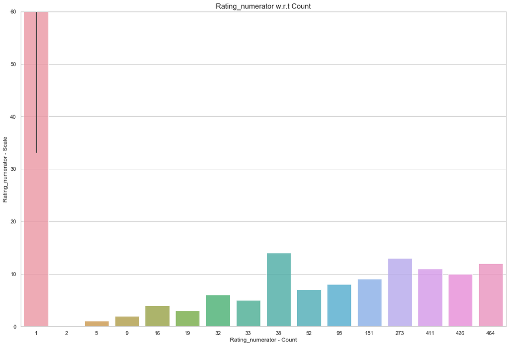

```python
from IPython.display import Image
Image(filename='Rating_numerator.png')
```

```
Rating numerator have majority of the ratings around 10
```

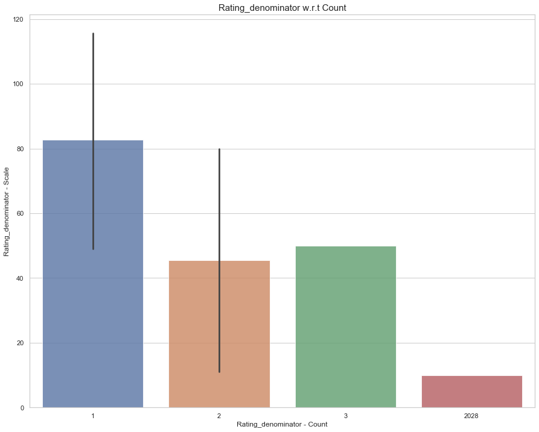

```python
from IPython.display import Image
Image(filename='Rating_denominator.png')
```